# Using QIIME2 artifacts in R

Alexey Larionov

Nov 2022

# Summary

This script illustrates how QIIME2 artifacts could be imported and used in R.

First, we import QIIME data to a **phyloseq** data type. R library **phyloseq** provides an extensive set of tools to analyse and visualize metagenomics data. This script only shows how to import QIIME2 data into **phyloseq** object. Then you may explore the richness of **phyloseq** functions yourselves: https://joey711.github.io/phyloseq

The **vegan** package is another popular R toolset for metagenomics analysis:  
https://rdrr.io/cran/vegan/man/vegan-package.html Here we use a very popular function **vegan::adonis** to perform PERMANOVA.

Finally, just plain R still can be used to analyse and visualize data :)  
It is illustrated here by performing Hierarchical Clustering Analysis and plotting samples’ dendrogram.

# Install packages

Should be done once, so commented

```r
#install.packages("devtools")
#devtools::install_github("jbisanz/qiime2R")

#install.packages("BiocManager")
#BiocManager::install("phyloseq")
#BiocManager::install("vegan")

#install.packages("dendextend")
```

# Load packages

I suppressed all messages because some of these libraries are too chatty during loading

```r
suppressPackageStartupMessages(suppressWarnings(library(qiime2R))) # for importing QIIME2 artifacts
suppressPackageStartupMessages(suppressWarnings(library(phyloseq))) # for handling phyloseq objects
suppressPackageStartupMessages(suppressWarnings(library(vegan))) # for calculating PERMANOVA using adonis2()
suppressPackageStartupMessages(suppressWarnings(library(dendextend))) # for colouring samples dendrogram
```

# Locations of QIIME2 artifacts & metadata

Update this section to reflect the files location on your system!

```r
data_folder="C:/Users/alexe/metagenomics/results"
table_qza=file.path(data_folder,"s06b_rarefied_table.qza")
rooted_tree_qza=file.path(data_folder,"s05_rooted_tree.qza")
taxonomy_qza=file.path(data_folder,"s10_taxonomy.qza")

scripts_folder="C:/Users/alexe/metagenomics/scripts"
metadata_tsv=file.path(scripts_folder,"samples.txt")
```

# Import of QIIME2 artifacts & metadata to R

Import to **phyloseq** data type using **qiime2R** package. Then data could be further extracted from the **phyloseq** object, if necessary.

```r
# Convert QIIME2 artifacts & metadata to phyloseq
phy <- qza_to_phyloseq(table_qza, rooted_tree_qza, taxonomy_qza, metadata_tsv)

# Extract metadata and distance matrix from phyloseq object
metadata <- data.frame(sample_data(phy))
distance_matrix <- distance(phy, method="bray")
```

# Samples’ Hierarchical Clustering & Dendrogram

Formatting the dendrogram with general purpose **dendextend** R package.

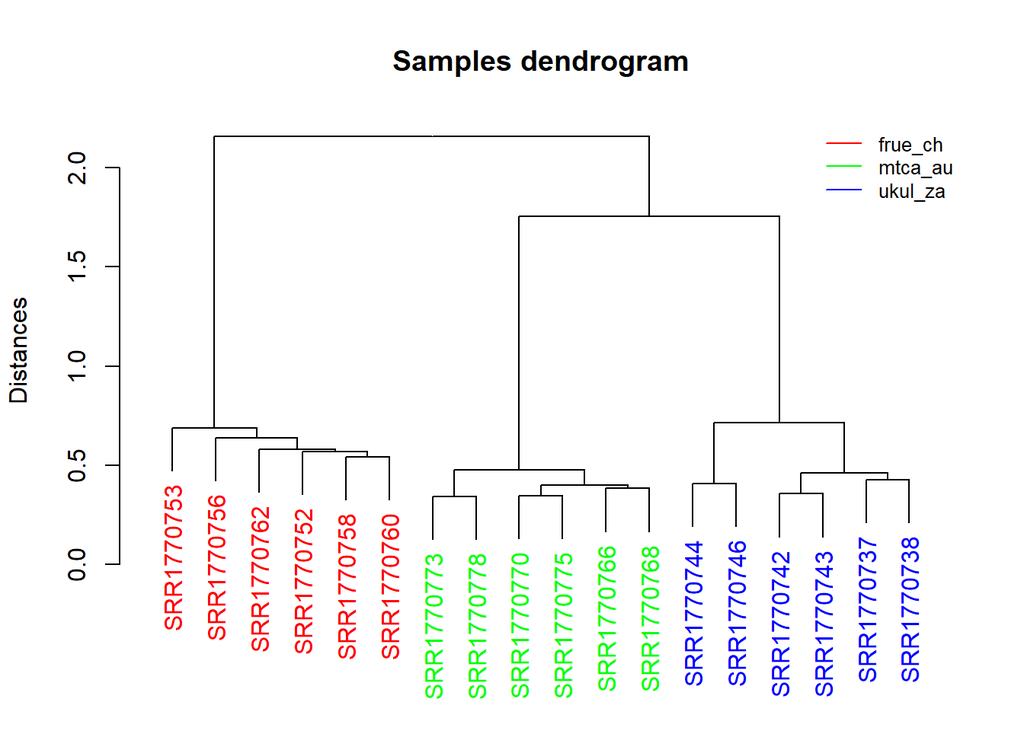

```r
bray_clust <- hclust(distance_matrix, method="ward.D2")
bray_dend <- as.dendrogram(bray_clust, hang=0.1)

colour_labels <- c('red','green','blue')[ match(as.factor(metadata$group),
                                                c('frue_ch','mtca_au','ukul_za') ) ]
labels_colors(bray_dend) <- colour_labels

plot(bray_dend, main="Samples dendrogram", ylab="Distances")

legend("topright",
       legend=c('frue_ch','mtca_au','ukul_za'),
       col=c('red','green','blue'),
       bty="n",lty=1, cex=0.8)
```

# PERMANOVA

Using **vegan::adonis**: the differences between studied groups are highly significant.

```r
# Run PERMANOVA
adonis2(distance_matrix ~ group, data = metadata, permutations=100000)
```

```
## Permutation test for adonis under reduced model
## Terms added sequentially (first to last)
## Permutation: free
## Number of permutations: 1e+05
##
## adonis2(formula = distance_matrix ~ group, data = metadata, permutations = 1e+05)
##          Df SumOfSqs      R2      F Pr(>F)
## group     2   3.8678 0.67051 15.262  1e-05 ***
## Residual 15   1.9007 0.32949
## Total    17   5.7685 1.00000
## ---
## Signif. codes:  0 '***' 0.001 '**' 0.01 '*' 0.05 '.' 0.1 ' ' 1
```